# histograms_with_seaborn

## Histogram with seaborn

```python
import numpy as np
import pandas as pd
import matplotlib.pyplot as plt

import seaborn as sns
```

```python
penguins = sns.load_dataset('penguins')
```

```python
penguins.info()
```

```
<class 'pandas.core.frame.DataFrame'>
RangeIndex: 344 entries, 0 to 343
Data columns (total 7 columns):
 #   Column             Non-Null Count  Dtype
---  ------             --------------  -----
 0   species            344 non-null    object
 1   island             344 non-null    object
 2   bill_length_mm     342 non-null    float64
 3   bill_depth_mm      342 non-null    float64
 4   flipper_length_mm  342 non-null    float64
 5   body_mass_g        342 non-null    float64
 6   sex                333 non-null    object
dtypes: float64(4), object(3)
memory usage: 18.9+ KB
```

```python
penguins.describe()
```

|  | bill_length_mm | bill_depth_mm | flipper_length_mm | body_mass_g |
| --- | --- | --- | --- | --- |
| count | 342.000000 | 342.000000 | 342.000000 | 342.000000 |
| mean | 43.921930 | 17.151170 | 200.915205 | 4201.754386 |
| std | 5.459584 | 1.974793 | 14.061714 | 801.954536 |
| min | 32.100000 | 13.100000 | 172.000000 | 2700.000000 |
| 25% | 39.225000 | 15.600000 | 190.000000 | 3550.000000 |
| 50% | 44.450000 | 17.300000 | 197.000000 | 4050.000000 |
| 75% | 48.500000 | 18.700000 | 213.000000 | 4750.000000 |
| max | 59.600000 | 21.500000 | 231.000000 | 6300.000000 |

```python
penguins['species'].value_counts()
```

```
Adelie       152
Gentoo       124
Chinstrap     68
Name: species, dtype: int64
```

```python
penguins['island'].value_counts()
```

```
Biscoe       168
Dream        124
Torgersen     52
Name: island, dtype: int64
```

```python
penguins['sex'].value_counts()
```

```
Male      168
Female    165
Name: sex, dtype: int64
```

## Histograms to visualize a distribution

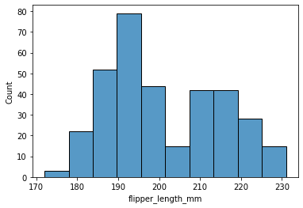

```python
sns.histplot(data = penguins, x='flipper_length_mm')
plt.show()
```

Use fewer bins to have coarser resolution of the distribution.

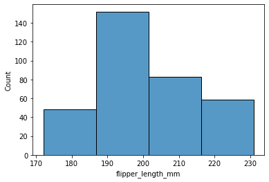

```python
sns.histplot(data=penguins, x='flipper_length_mm', bins=4)
plt.show()
```

Use more bins, we will have fewer observations per bin.

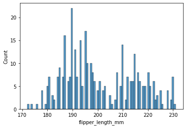

```python
sns.histplot(data=penguins, x='flipper_length_mm', bins=85)
plt.show()
```

Create our own discrete variable of the `flipper_length_mm`. So we will convert `flipper_length_mm` into a Categorical variable using the `pd.cut()`.

```python
penguins['flipper_cat'] = pd.cut(penguins.flipper_length_mm, bins=4, include_lowest=True, ordered=True)
```

```python
penguins.flipper_cat.value_counts()
```

```
(186.75, 201.5]     152
(201.5, 216.25]      83
(216.25, 231.0]      59
(171.94, 186.75]     48
Name: flipper_cat, dtype: int64
```

Use seaborn to plot the number of observations per unique value of `flipper_cat`.

```python
penguins.head()
```

|  | species | island | bill_length_mm | bill_depth_mm | flipper_length_mm | body_mass_g | sex | flipper_cat |
| --- | --- | --- | --- | --- | --- | --- | --- | --- |
| 0 | Adelie | Torgersen | 39.1 | 18.7 | 181.0 | 3750.0 | Male | (171.94, 186.75] |
| 1 | Adelie | Torgersen | 39.5 | 17.4 | 186.0 | 3800.0 | Female | (171.94, 186.75] |
| 2 | Adelie | Torgersen | 40.3 | 18.0 | 195.0 | 3250.0 | Female | (186.75, 201.5] |
| 3 | Adelie | Torgersen | NaN | NaN | NaN | NaN | NaN | NaN |
| 4 | Adelie | Torgersen | 36.7 | 19.3 | 193.0 | 3450.0 | Female | (186.75, 201.5] |

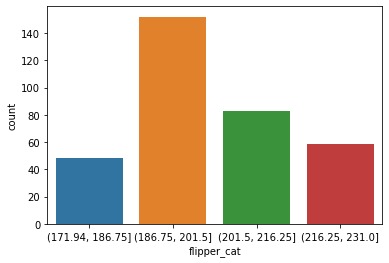

```python
sns.countplot(data=penguins, x='flipper_cat')
plt.show()
```

visualize the number of observations per unique value with Pandas.

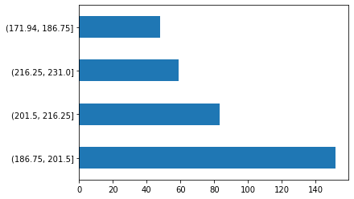

```python
fig, ax = plt.subplots()

penguins.flipper_cat.value_counts().plot(kind='barh', ax=ax)

plt.show()
```

### Graphically explore grouping our data different ways

Use the `sns.catplot()` FIGURE level function to create visualizations and apply them to a FIGURE object.

Use the FIGURE level functions to create subplots - FACETS - in one line of code. Do this when we want the FACETS to represent different unique values of variables.

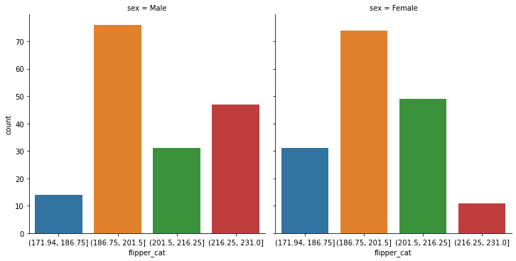

```python
sns.catplot(data=penguins, x='flipper_cat', col='sex', kind='count')

plt.show()
```

We can also use the COLOR, which Seaborn names as the `hue` to "break up" variables.

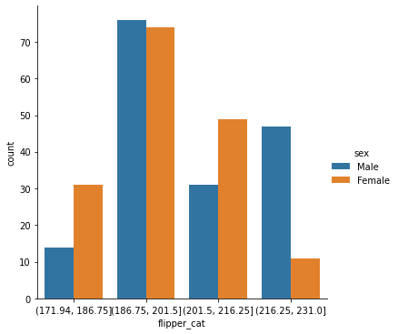

```python
sns.catplot(data=penguins, x='flipper_cat', hue='sex', kind='count')

plt.show()
```

How does the data "break up" by `island`?

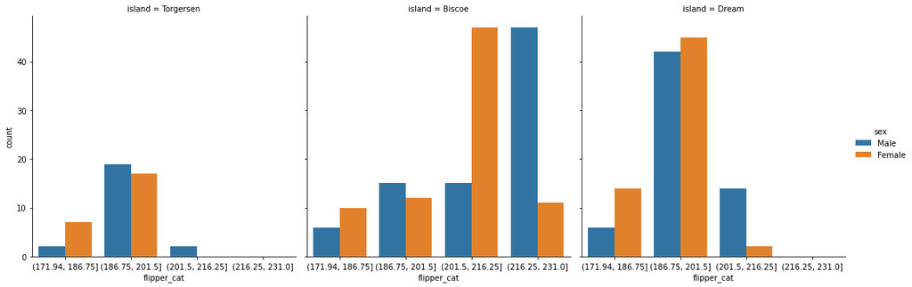

```python
sns.catplot(data=penguins, x='flipper_cat', hue='sex', col='island',
          kind='count')

plt.show()
```

Further FACETS associated with the ROW based on the `species`.

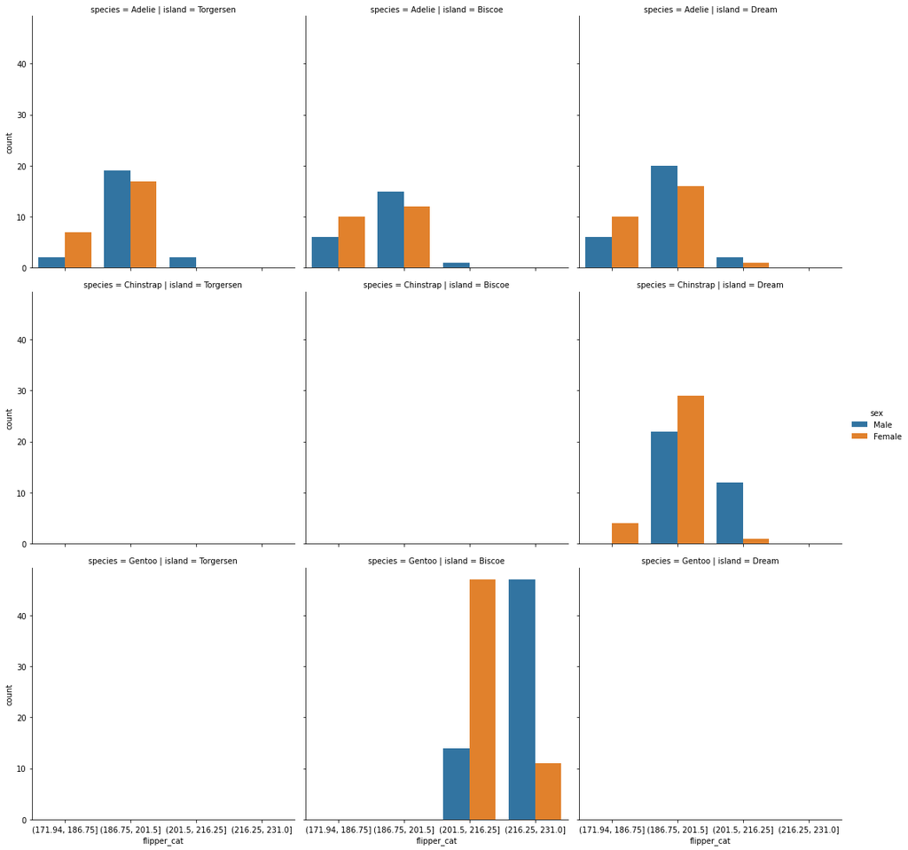

```python
sns.catplot(data=penguins, x='flipper_cat', hue='sex',
            col='island', row='species',
           kind='count')

plt.show()
```

Double check that this figure makes sense by using `.groupby()` to count the number of rows associated with each combination of `species` and `island`.

```python
penguins.groupby(['species', 'island']).size().reset_index(name='num_rows')
```

|  | species | island | num_rows |
| --- | --- | --- | --- |
| 0 | Adelie | Biscoe | 44 |
| 1 | Adelie | Dream | 56 |
| 2 | Adelie | Torgersen | 52 |
| 3 | Chinstrap | Dream | 68 |
| 4 | Gentoo | Biscoe | 124 |

[figure not shown]

```python
sns.catplot(data=penguins, x='flipper_cat', hue='sex',
            col='island', row='species',
           kind='count',
           height=1)

plt.show()
```

Use a 2D histogram to visualize the COUNTS of the combinations of `species` and `island`.

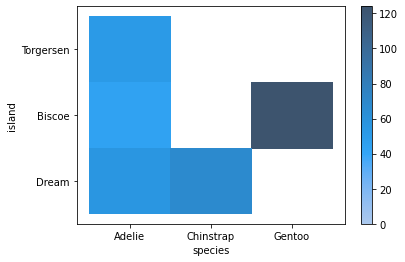

```python
sns.histplot(data=penguins, x='species', y='island', discrete=(True,True),
            stat='count', cbar=True)

plt.show()
```

### Change the style or theme of the figures

```python
sns.set_style('darkgrid')
```

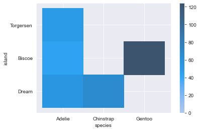

```python
sns.histplot(data=penguins, x='species', y='island', discrete=(True,True),
            stat='count', cbar=True)

plt.show()
```

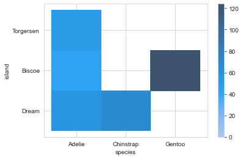

```python
sns.set_style('whitegrid')

sns.histplot(data=penguins, x='species', y='island', discrete=(True,True),
            stat='count', cbar=True)

plt.show()
```

Return back to the histogram of our original numeric variable.

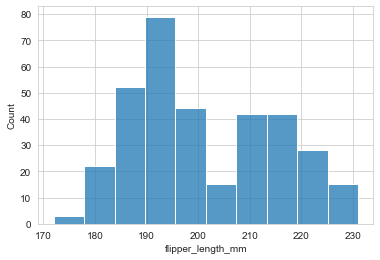

```python
sns.histplot(data=penguins, x='flipper_length_mm')

plt.show()
```

Use a density estimate to try and study a "smooth" version of the distribution. The FIGURE level funciton `sns.displot()`.

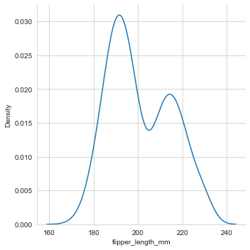

```python
sns.displot(data=penguins, x='flipper_length_mm', kind='kde')

plt.show()
```

What if we colored by the `species`?

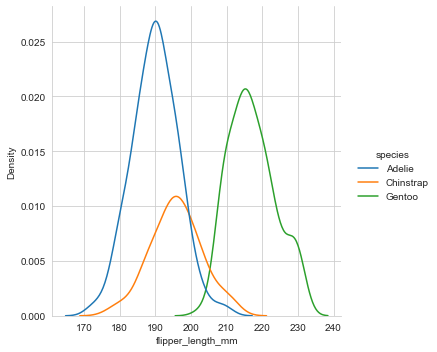

```python
sns.displot(data=penguins, x='flipper_length_mm', hue='species', kind='kde')

plt.show()
```

Add tick marks or "rugs" to our density plot. Use the AXES level functions `sns.kdeplot()` and `sns.rugplot()`.

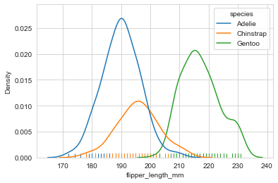

```python
sns.kdeplot(data=penguins, x='flipper_length_mm', hue='species')
sns.rugplot(data=penguins, x='flipper_length_mm', hue='species')

plt.show()
```